# Análise de Gastos de Deputados

Dandara Sousa

25 de outubro de 2017

## Introdução

Esta é uma análise sobre os gastos da Cota Parlamentar dos deputados no Brasil nos anos de 2015, 2016 e 2017. Veremos nesse post explanações sobre como os parlamentares estão usando essa Cota e como podemos visualizar esse gasto por estado, partido, tipo…

```r
dataCEAP <- read.csv("dadosCEAP.csv")
dataCEAP$valorGlosa <- as.numeric(sub(",", ".", dataCEAP$valorGlosa, fixed = TRUE))
names(dataCEAP)[13]<-"valorLíquido"
```

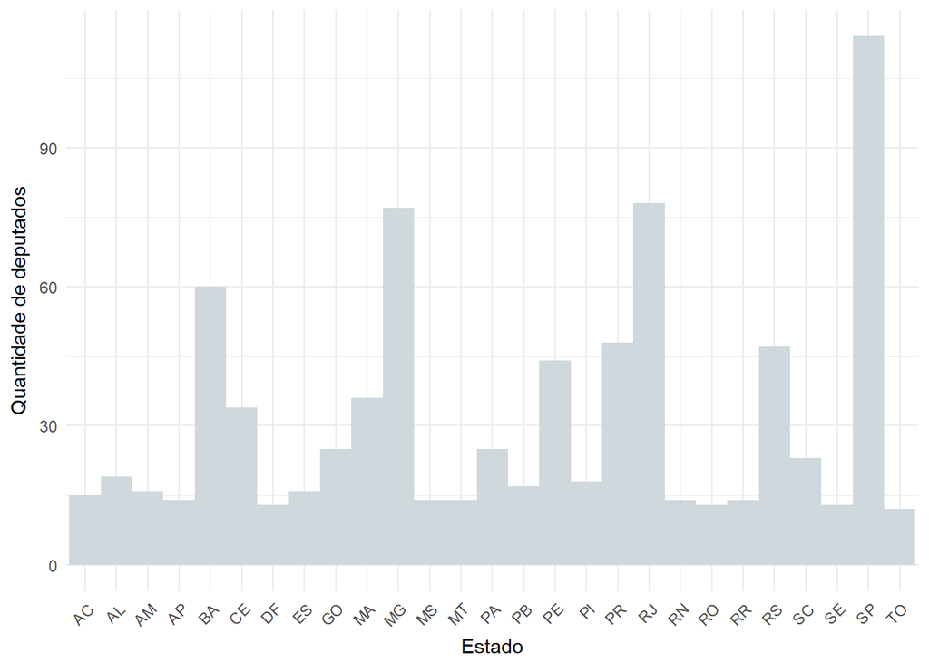

```r
dataCEAP %>%
  select(sgUF, nomeParlamentar) %>%
  unique() %>%
  group_by(sgUF) %>%
  filter(!sgUF %in% NA) %>%
  summarise(n = n())%>%
  ggplot(aes(x=sgUF, n))+
  geom_bar(width = 1, stat = "identity", fill = "#cfd8dc") +
  theme(axis.text.x = element_text(angle = 45, hjust = 1)) +
  labs(x="Estado",y="Quantidade de deputados")
```

## Quais os partidos que mais fazem uso da CEAP? Quais os partidos que menos fazem uso? Mesmas perguntas considerando valores em R$.

Para responder nossa primeira pergunta vamos olhar em como os partidos usam a CEAP.

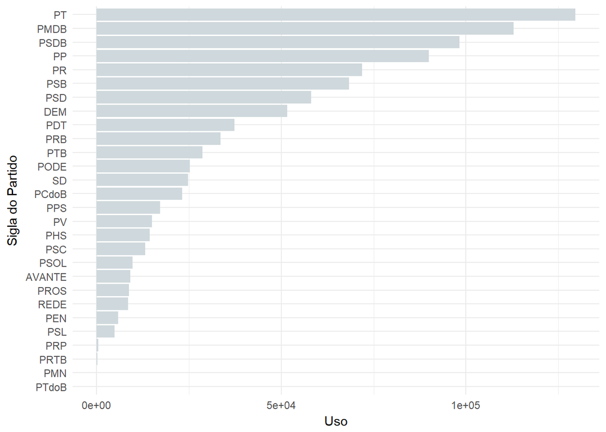

```r
dataCEAP %>%
  group_by(sgPartido) %>%
  filter(!sgPartido %in% NA) %>%
  summarise(n = n()) %>%
  ggplot(aes(x = reorder(sgPartido, n), y = n)) +
  geom_bar(stat = "identity", fill = "#cfd8dc") +
  coord_flip() +
  labs(x="Sigla do Partido",y="Uso")
```

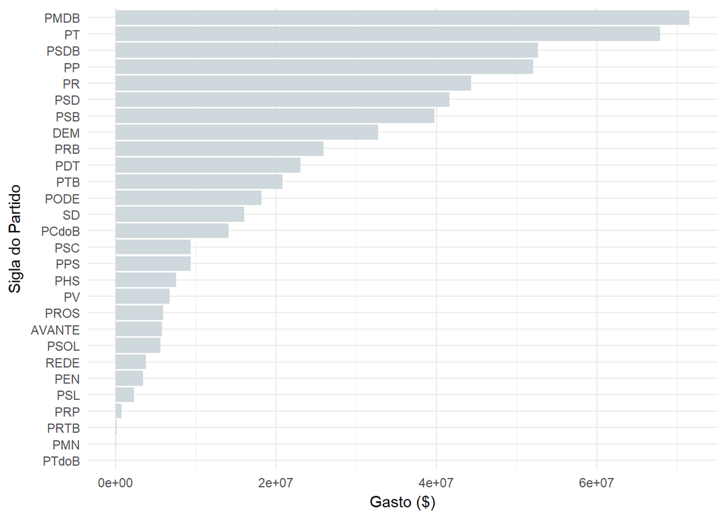

```r
dataCEAP %>%
  group_by(sgPartido) %>%
  filter(!sgPartido %in% NA) %>%
  summarise(n = sum(valorLíquido)) %>%
  ggplot(aes(x = reorder(sgPartido, n), y = n)) +
  geom_bar(stat = "identity", fill = "#cfd8dc") +
  coord_flip() +
  labs(x="Sigla do Partido",y="Gasto ($)")
```

Novamente com gráfico de barras podemos analisar os gastos com a CEAP. Nesse caso é possível ver que mais comunente se usa a CEAP para custear emissão de bilhete aéreo, combustíveis e lubrificantes e telefonia. Isso pode ser justificado se levar em consideração que no âmbito de carreira do parlamento as viagens são rotineiras.

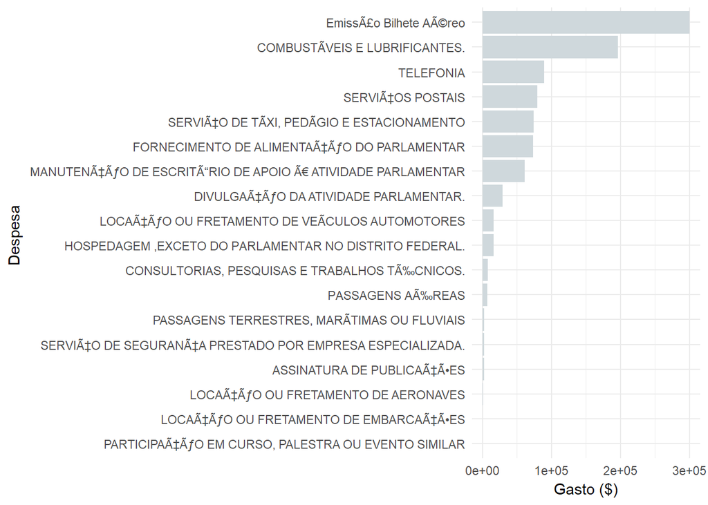

```r
dataCEAP %>%
  group_by(tipoDespesa) %>%
  filter(!sgPartido %in% NA) %>%
  summarise(n = n()) %>%
  ggplot(aes(x = reorder(tipoDespesa,n), y = n)) +
  geom_bar(stat = "identity", fill = "#cfd8dc") +
  coord_flip() +
  labs(x="Despesa ",y="Gasto ($)")
```

## Levando em conta o estado pelo qual o deputado se elegeu, quais os estados que mais fazem uso da CEAP? Quais os que menos fazem uso? Mesmas perguntas considerando gastos em R$. Por que você acha isso?

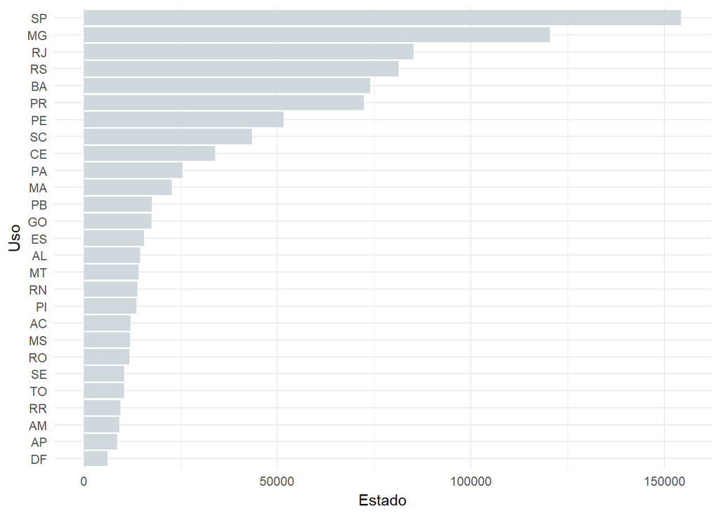

```r
dataCEAP %>%
  group_by(sgUF) %>%
  filter(!sgUF %in% NA) %>%
  summarise(n = n()) %>%
  ggplot(aes(x = reorder(sgUF, n), y = n)) +
  geom_bar(stat = "identity", fill = "#cfd8dc") +
  coord_flip() +
  labs(x="Uso",y="Estado")
```

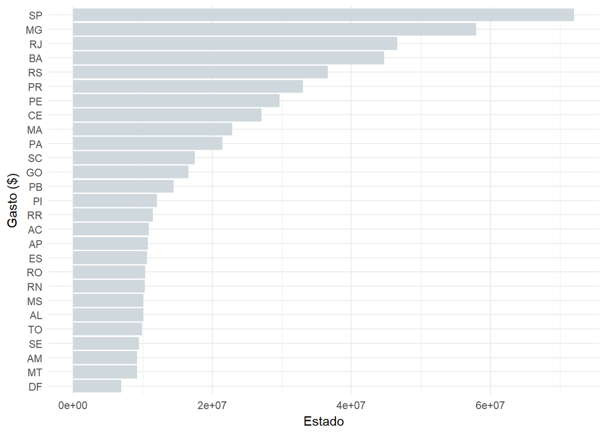

```r
dataCEAP %>%
  group_by(sgUF) %>%
  filter(!sgUF %in% NA) %>%
  summarise(n = sum(valorLíquido)) %>%
  ggplot(aes(x = reorder(sgUF, n), y = n)) +
  geom_bar(stat = "identity", fill = "#cfd8dc") +
  labs(x="Gasto ($)",y="Estado") +
  coord_flip()
```

A partir de ambos os gráficos vemos que a situação se repete de certa forma. São Paulo é o estado quem mais usa e gasta da CEAP, seguido de Minas Gerais e Rio de Janeiro. O que de certa forma previmos já que São Paulo é de longe o estado com maior presença parlamentar.

## Quais os parlamentares que mais gastam com CEAP e quais os que menos gastam?

```r
data.dep <- dataCEAP %>%
  group_by(nomeParlamentar) %>%
  summarise(n = sum(valorLíquido))
```

Os deputados que mais gastaram e menos gastaram respectivamente são:

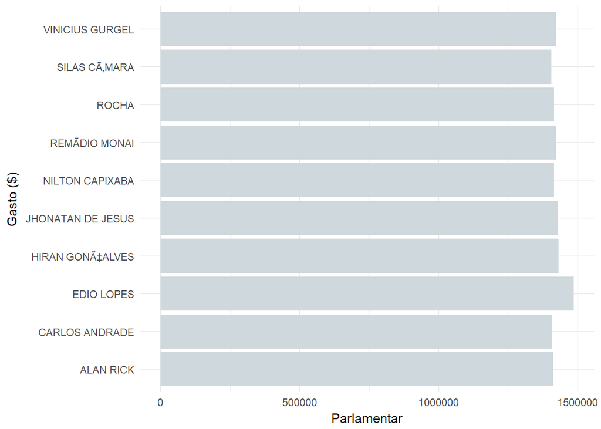

```r
data.dep[order(-data.dep$n),] %>%
  head(10) %>%
  ggplot(aes(x = nomeParlamentar, y = n)) +
  geom_bar(stat = "identity", fill = "#cfd8dc") +
  coord_flip()+
  labs(x="Gasto ($)",y="Parlamentar")
```

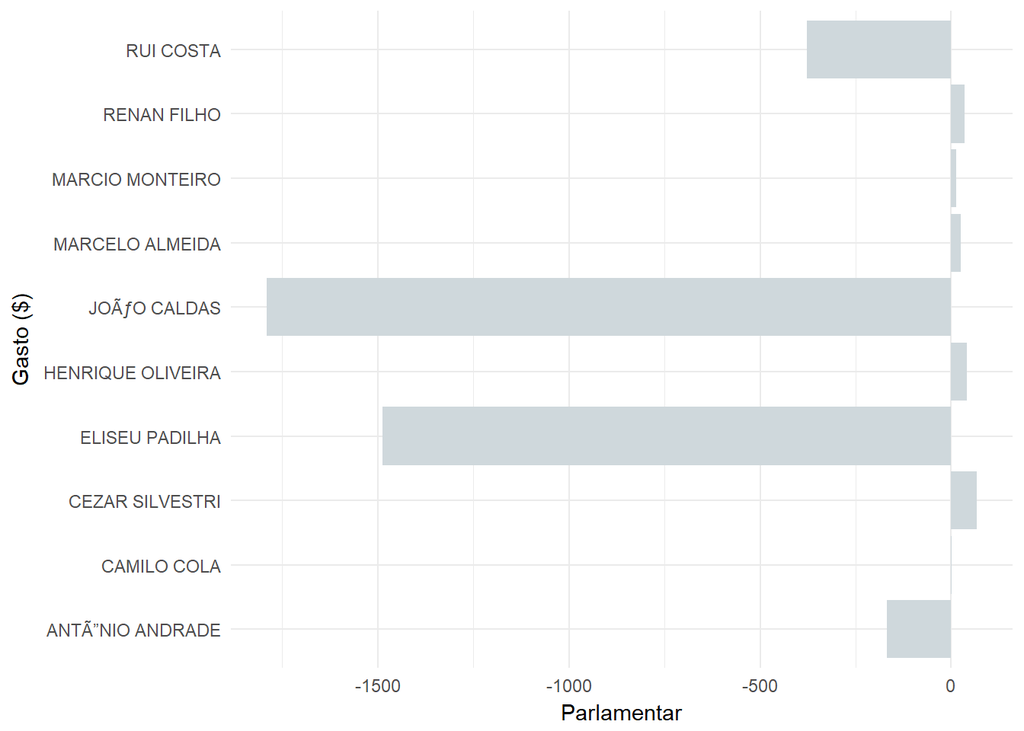

```r
data.dep[order(data.dep$n),] %>%
  head(10) %>%
  ggplot(aes(x = nomeParlamentar, y = n)) +
  geom_bar(stat = "identity", fill = "#cfd8dc") +
  coord_flip() +
  labs(x="Gasto ($)",y="Parlamentar")
```

## Existe correlação entre a quantidade de gastos no exterior e o valor restituído da CEAP?

A partir do exposto abaixo é possível perceber que não há correlação entre as variáveis.

```r
dataCEAP.dep <- dataCEAP %>%
  group_by(nomeParlamentar) %>%
  summarise(sGastos = sum(valorLíquido))

dataCEAP.dep.exterior <- dataCEAP %>%
  filter(tipoDocumento == 2) %>%
  group_by(nomeParlamentar) %>%
  summarise(nGastos = n())

dataCEAP.dep.exterior %>%
  left_join(dataCEAP.dep, by= "nomeParlamentar") %>%
  select(sGastos, nGastos) %>%
  cor()
```

```
##              sGastos      nGastos
## sGastos  1.000000000 -0.003793119
## nGastos -0.003793119  1.000000000
```